# hw4_llindy_colab

## Homework 4: Social Network Analysis

## CSC401: Data Mining and Machine Learning

## Dr. Scott Spurlock

### 4/26/2020 (due date)

**Notes to the Instructor:**

- *Apologies for all the code commentary inline and after each questions. Trying not to just go through the motions.*
- *Images or screenshots of the different networks are viewable inline, but are also included zipped into the folder accompanying this .ipynb and/or .html file*
- *I am really sorry that this is late; I really wanted to get the extra credit to work*
- *Important note: basemap does not seem to work in google colab and using the updated cartography crashes the kernel so if you are dying to use colab, you made need a work around for next year. I ended up using Jupyter Notebook as part of Anaconda as a result*

# 1: General Setup

## 1a: Refer to file name.

## 1b: Refer to header cell

## 1c: Imports

```python
# standard imports
import numpy as np

import pandas as pd

import statistics as sts

import matplotlib.pyplot as plt
%matplotlib inline

from sklearn.model_selection import train_test_split
from sklearn import tree
from sklearn.metrics import confusion_matrix

import pylab as plt
%matplotlib inline

# for text analysis
import nltk
import string

# for counting
from collections import Counter

# seaborn
import seaborn as sns
import matplotlib.pyplot as plt
sns.set(style="ticks", color_codes=True)

# for using Google CoLab
# from google.colab import drive
# drive.mount('/content/drive')

# for doing the SNA
import networkx as nx # specific imports
import re # to use regex
from collections import Counter # for analysis
import operator # for analysis
from operator import itemgetter # for analysis
import csv # for file compatibility
import json # for file compatibility

# for using dicts
from operator import itemgetter

# **some context specfic imports are sprinkled throughout as well**
```

## 1d: read in the data flle

```python
# path = '/content/drive/My Drive/Colab Notebooks/DMML Data Files/twitter_enviroed.csv' # set the file path
path = 'twitter_enviroed.csv' # set the file path
data = pd.read_csv(path, sep=',') # read in the master data frame
print(len(data)) # get the length
data.head() # return the head to visualize a few rows
```

```
5514
```

|  | Date | Screen Name | Full Name | Tweet Text | Tweet ID | App | Followers | Follows | Retweets | Favorites | Verfied | User Since | Location | Bio | Profile Image |
| --- | --- | --- | --- | --- | --- | --- | --- | --- | --- | --- | --- | --- | --- | --- | --- |
| 0 | 3/15/16 | @_Lightscap3s_ | Otis | RT @NatureBridge: "NatureBridge is Highlight o... | 7.100000e+17 | RoundTeam | 2644 | 590.0 | 1 | 0 | No | 6/8/09 | Carmel, IN | Artist @ Framed Lightscap3s LLC \| Landscape, M... | View |
| 1 | 3/21/16 | @_Lightscap3s_ | Otis | RT @NatureBridge: By 2050 we want more fish th... | 7.120000e+17 | RoundTeam | 2641 | 587.0 | 2 | 0 | No | 6/8/09 | Carmel, IN | Artist @ Framed Lightscap3s LLC \| Landscape, M... | View |
| 2 | 4/6/16 | @_Lindsay_Conway | Lindsay | RT @savageducates: Greenest School on #Earth s... | 7.180000e+17 | Twitter for iPhone | 164 | 318.0 | 2 | 0 | No | 6/7/14 | Bratislava, Slovakia | International education. SEN interests. Adopti... | View |
| 3 | 3/23/16 | @_mcisneros19 | Mirella Cisneros | A1: For math children could measure trunks to ... | 7.130000e+17 | TweetDeck | 8 | 44.0 | 0 | 0 | No | 2/4/16 | NaN | NaN | View |
| 4 | 3/23/16 | @_mcisneros19 | Mirella Cisneros | A2: Going outside & letting children find the ... | 7.130000e+17 | TweetDeck | 8 | 44.0 | 0 | 0 | No | 2/4/16 | NaN | NaN | View |

# 2: Answer the following questions in Markdown cells, including code and a graph where needed.

## 2a: What are your observations about how often the various apps (e.g., TweetDeck, Twitter for iPhone) are used to tweet? Show a visualization.

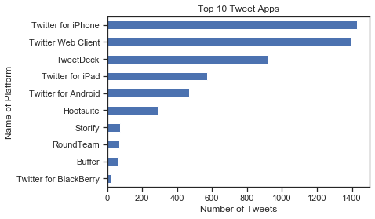

```python
df2a = data.copy() # make a copy of the original data set to preserve original
wide = df2a.App.value_counts() # get the data needed to plot; a list
n = 10 # set the number of platforms to be kept
plot = wide.nlargest(n).plot(kind='barh').invert_yaxis() # generate the plot
plt.title("Top 10 Tweet Apps") # add a title
plt.xlabel("Number of Tweets") # add the x-axis label
plt.ylabel("Name of Platform") # add the y-axis label
plt.show() # plot the visualization
```

#### **Coding commentary for 2a:**

I chose to use a horizontal bar graph because I think they are far superior to vertical bar graphs when trying to show ordinal data along with counts. Here the number of tweets per platform is less relevant than the order of the platforms and using the horizontal bar graph brings attention to that order.

#### **Observations for 2a:**

Most Tweets come from either the iPhone app or the Web Client with their enterprise Tweet management platform, TweetDeck, being a distant third and other platforms trickling off after that. This is an important metric for Twitter to pay attention to, because they can then use it to make decisions on how to spend research and development dollars on various platforms.

## 2b. What are your observations about how many original tweets there are compared to retweets (original contributions vs. amplification of others)? (Note that retweets start with the text RT and a username that starts with @.) Show a visualization.

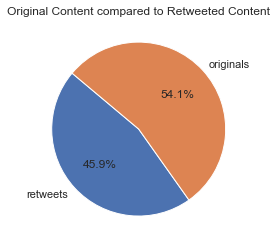

```python
df2b = data.copy() # copy the data
retweets = sum([tweet[:4] == 'RT @' for tweet in df2b['Tweet Text']]) # get the number of retweets
originals = len(df2b) - retweets # get the number of originals
sizes = [retweets, originals] # set the porportions
labels = ['retweets', 'originals'] # set the labels
plt.pie(sizes, labels=labels,autopct='%1.1f%%', startangle=140) # generate the plot
plt.title("Original Content compared to Retweeted Content") # add a title
plt.show() # plot the visualization
```

#### **Coding Commentary for 2b:**

I went with a pie chart because a bar chart with two bars makes it hard to see composition, which is what this visual is trying to demonstrate. A simple, fairly standard implementation of a pie chart is used. While a pie chart is not my favorite visual, it is useful to see composition and when paired with a label (such as this case), it can get the point across.

I enjoyed using a list comprehension then calling the sum on it. The list comprehension creates a list of booleans that can then be summed to represent the number of tweets that are retweets. Another interesting way to have done this would have been using regular expressions, however, when the format for all retweets is the same and they are going to be in the smame position literal positioning worked well too.

#### **Observations for 2b:**

The visual shows that there is a fairly even distribution of content between original content and retweets; this is useful to know, because it shows the depth of the network that twitter is where slightly less than half of it is people tweeting about other people's tweets. This is a repetitive theme, but it is important to note that this is representative of this subset of the twitterverse not necessarily all of twitter.

## 2c: How often are there replies to tweets (showing interaction among people). Note that replies start with @username to show they are a reply to a specific user. Show a visualization.

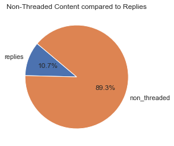

```python
df2c = data.copy() # copy the data
replies = sum([tweet[:1] == '@' for tweet in df2b['Tweet Text']]) # get the number of retweets
non_threaded = len(df2c) - replies # get the number of originals
sizes = [replies, non_threaded] # set the porportions
labels = ['replies', 'non_threaded'] # set the labels
plt.pie(sizes, labels=labels,autopct='%1.1f%%', startangle=140) # generate the plot
plt.title("Non-Threaded Content compared to Replies") # add a title
plt.show() # plot the visualization
```

#### **Observations for 2c:**

This shows that for this data set, almost 90% of tweets are either the start of threads or otherwise not in reply to another tweet. It would be interesting to compare this number across all of Twitter.

Again, a pie chart is not an ideal visualization, but it is proper in this context because it is being used to show compostition which is why pie charts are commonly used.

## 2d: What are your observations about the distribution of followers counts (i.e., how many other users were following the poster of a given tweet)? Show a visualization. Note that the distribution of a single numeric column is generally best shown with a histogram.

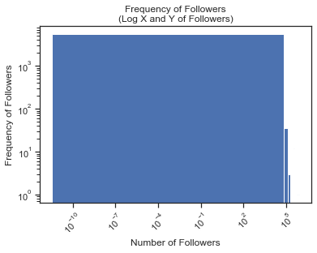

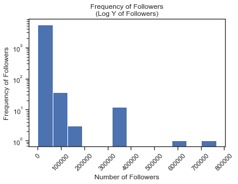

```python
df2d = data.copy() # create a copy of the data for this question
followers = df2d.Followers # subset the data
n = 12 # number of bins to show

# explore getting reasonable results by logging the x and y axes
followers.plot(kind = 'hist', bins = n, logy = True, logx = True, rot = 45) # generate the histogram of followers (logged x and y axis)
plt.title("Frequency of Followers\n(Log X and Y of Followers)") # set the title
plt.xlabel("Number of Followers") # set the x-axis label
plt.ylabel("Frequency of Followers") # set the y-axis label
plt.show() # show the plot

# explore getting reasonable results by logging just the y-axis
followers.plot(kind = 'hist', bins = n, logy = True, logx = False, rot = 45) # generate the histogram of followers (logged y-axis)
plt.title("Frequency of Followers\n(Log Y of Followers)") # set the title
plt.xlabel("Number of Followers") # set the x-axis label
plt.ylabel("Frequency of Followers") # set the y-axis label
plt.show() # show the plot
```

#### **Coding Commentary for 2d:**

This one is pretty simple, but this question really underscored the value in toying with settings for a plot. If I had not toyed with the settings and realized that the y axis needed to be logged, I wouldn;t have learned hey insights about how disperesed the follower counts were. I made the first plot to demonstrate the differences in the settings.

#### **Observations for 2d:**

This histogram shows that the vast, vast majority of twitter have below 200,000 followers. This makes a lot of sense, because we would consider 200,000 to be a lot.

Toying with the settings in matplotlib was a critical step for this to understand the data better. Had I not logged the y-axis, the data would not nearly have been as insightful.

## 2e: What are your observations about the distribution of follows counts (i.e., how many other accounts are followed by the poster of a given tweet) and how does it compare to the distribution of followers counts? Show a visualization.

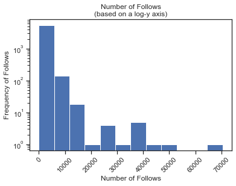

```python
df2e = data.copy() # generate a copy of the data for this question
follows = df2e.Follows # subset out the number of followers
n = 12 # number of bins
follows.plot(kind = 'hist', bins = n, logy = True, logx = False, rot = 45) # make a histogram based on followers
plt.title("Number of Follows\n(based on a log-y axis)") # add a title
plt.xlabel("Number of Follows") # add an x label
plt.ylabel("Frequency of Follows") # add a y label
plt.show() # show the plot
```

#### **Code Commentary for 2e:**

I definetly applied what I had learned from the previous visualization to tailor this graph. It is very similar to the previous one in that sense. In terms of the implementation, it was a breeze because its just a simple plot.

## 2f: Where are people tweeting? We don’t have complete or easily parsed location data unfortunately. For a quick analysis, we can use the Location column, which is populated based on whatever a given user added in their profile on Twitter, although this may be blank or contain unhelpful information. Make two graphs showing the top 25 locations, one based on number of tweets sent from that location, and one based on number of users from that location.

### 2f (1): tweets from the locations

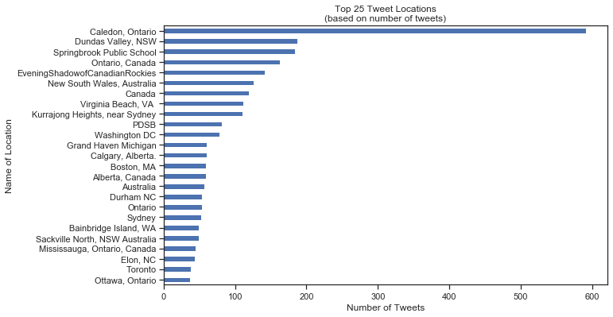

```python
df2f1 = data.copy() # make a copy of the original data set to preserve original
locations = df2f1.Location.value_counts() # get the data needed to plot
n = 25 # set the number of locations to be kept
plot = locations.nlargest(n).plot(kind='barh', figsize = (10,6)).invert_yaxis() # generate the plot
plt.title("Top 25 Tweet Locations\n(based on number of tweets)") # add a title
plt.xlabel("Number of Tweets") # add the x-axis label
plt.ylabel("Name of Location") # add the y-axis label
plt.figure(figsize=(60,50)) # adjust size
plt.show() # plot the visualization
```

#### **2f (1) Coding Commentary:**

This one was the easier of the two. I pulled back a horizontal bar chart to once again capitalize on the access. Otherwise, the implementation was fairly straightforward.

#### **2f (1) Observations:**

Clearly that for this data set of teachers Caledon, Ontario is the most populously tweeted from location. More data science would have to be done on this information to see if there is a power user there (my hunch is that there is) or a district that is super into tweeting.

### 2f(2): users per location

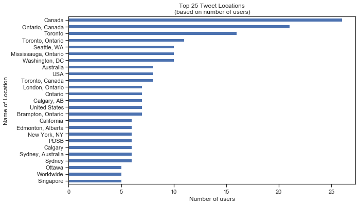

```python
df2f2 = data.copy() # make a copy of the original data set to preserve original
locations = df2f2[['Location','Screen Name']] # subset the data
locations = locations.drop_duplicates(subset = 'Screen Name') # remove duplicates based on screen name
locations = locations.Location.value_counts() # get the remaining value
n = 25 # set the number of locations to be kept
plot = locations.nlargest(n).plot(kind='barh', figsize = (10,6)).invert_yaxis() # generate the plot
plt.title("Top 25 Tweet Locations\n(based on number of users)") # add a title
plt.xlabel("Number of users") # add the x-axis label
plt.ylabel("Name of Location") # add the y-axis label
plt.figure(figsize=(60,50)) # adjust size
plt.show() # plot the visualization
```

#### **2f (2) Coding Commentary:**

This one was the easier of the two. I pulled back a horizontal bar chart to once again capitalize on the access. Otherwise, the implementation was fairly straightforward. Since we only care about users in this case, we can drop all duplicates on screen name. After that, getting value counts is simple and plot from there. I used some print statements to test and see how it was doing.

## 2g: When are people tweeting? Discuss your observations of when people tweet by analyzing the date column. Make a graph showing the number of tweets sent for each day of the week (Monday through Sunday). You may need to Google a bit for help with working with dates. Note that when you’re working with categories that are always displayed in a certain order (like days of the week), it is generally confusing to your audience to change the order in a graph.

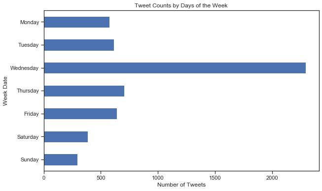

```python
import calendar # to get my days of week
df2g = data.copy() # create a working copy
df2g['week_day'] = pd.to_datetime(df2g.Date).dt.weekday # create a new column of numerical days of week
df2g['week_day'] = [calendar.day_name[i] for i in df2g.week_day] # update using list comprehesion


plot = df2g['week_day'].value_counts().reindex(['Monday', 'Tuesday', 'Wednesday', 'Thursday', 'Friday', 'Saturday', 'Sunday']).plot(kind='barh', figsize = (10,6)).invert_yaxis() # generate the plot
plt.title("Tweet Counts by Days of the Week") # add a title
plt.xlabel("Number of Tweets") # add the x-axis label
plt.ylabel("Week Date") # add the y-axis label
plt.figure(figsize=(60,50)) # adjust size
plt.show() # plot the visualization
```

#### **2g Observations:**

This visual shows that Wednesday is the most popular day of the week to tweet. This is useful for twitter to know so that they can promote the most content, and optimize their cloud computing storage capacities to fit this day. Again, it goes without saying, that to explain the causation more investigative study would have to be done.

## 2h: What are people tweeting? Discuss your observations of the content of the tweets, based on the Tweet Text column. Make two graphs, one showing the top 50 most common words used in tweets, and one showing the top 20 most common topics (words starting with '#')

### 2h.i: Regular Tweet Text

```
Unique terms: 7925

The 50 Most common terms (automatically sorted):
[('enviro', 5257), ('rangerridley', 783), ('chat', 545), ('educ', 492), ('learn', 435), ('teacher', 431), ('natur', 410), ('student', 379), ('school', 369), ('great', 350), ('https…', 318), ('outdoor', 310), ('environment', 254), ('peelschool', 252), ('use', 246), ('love', 244), ('day', 238), ('may'…
```

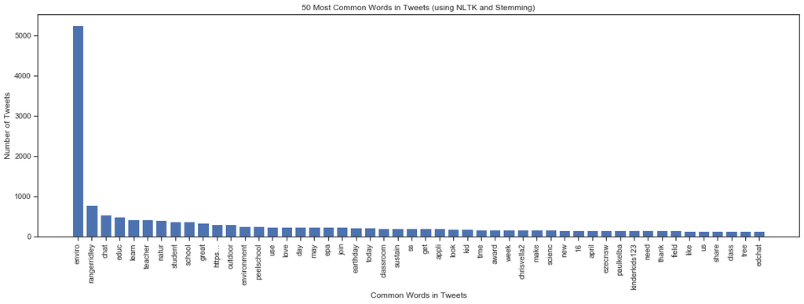

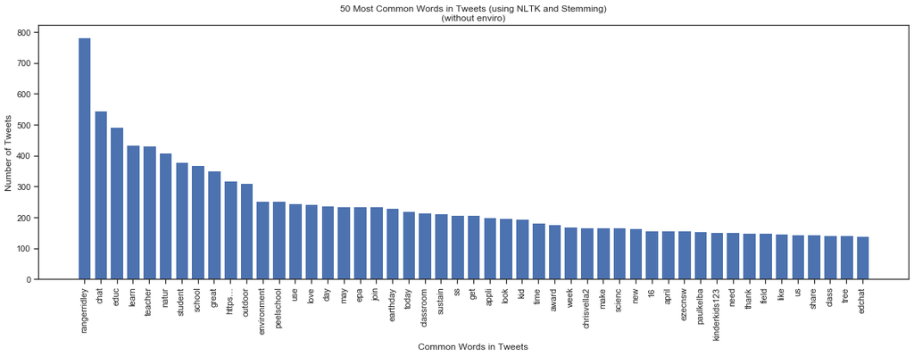

```python
df2h = data.copy() # data copy for this question

# couple of imports
import nltk
import string
# May need this if not already installed
nltk.download('stopwords')
nltk.download('punkt')


# function for doc conversion
def convert_doc_string_to_terms(doc):
    # prep doc
    stemmer = nltk.stem.porter.PorterStemmer() # instantiate the stemmer
    fixed = doc.lower().translate(str.maketrans('', '', string.punctuation)) # clean up the string

    # do the steps
    tokens = nltk.word_tokenize(fixed) # generate the tokens
    noStops = [word for word in tokens if (not word in nltk.corpus.stopwords.words('english')) and (word != 'rt')] # remove stop words with list comprehension
    stemmed = [stemmer.stem(word) for word in noStops] # stem the words using list comprehension
    return stemmed # return the completed list of words

results = [ convert_doc_string_to_terms(doc) for doc in df2h['Tweet Text']] # run the conversion on all tweet words
tc = nltk.TextCollection(results) # creates text collection
fdist = tc.vocab() # creates the frequency distribution

unique_terms = list(fdist.keys()) # generates a list of unique terms
num_terms = len(unique_terms) # generates the number of unique terms
print('\nUnique terms:', num_terms) # some output to demonstrate success
print('\nThe 50 Most common terms (automatically sorted):') # output to show top 50 terms
print(fdist.most_common(50)) # top 50 terms
out = fdist.most_common(50) # stores the top 50 terms
plt.figure(figsize=(20,6)) # sets a fig size
plt.title("50 Most Common Words in Tweets (using NLTK and Stemming)") # sets a title
plt.bar(range(len(out)), [val[1] for val in out], align='center') # uses list comprehension inline to generate the plot
plt.xticks(range(len(out)), [val[0] for val in out]) # generates the xticks using list comprehension
plt.xticks(rotation=90) # allows for easy reading
plt.xlabel('Common Words in Tweets') # sets the x label
plt.ylabel('Number of Tweets') # sets the y label
plt.show() # shows the plot

out = fdist.most_common(50)[1:] # stores the top 49 terms
plt.figure(figsize=(20,6)) # sets a fig size
plt.title("50 Most Common Words in Tweets (using NLTK and Stemming)\n(without enviro)") # sets a title
plt.bar(range(len(out)), [val[1] for val in out], align='center') # uses list comprehension inline to generate the plot
plt.xticks(range(len(out)), [val[0] for val in out]) # generates the xticks using list comprehension
plt.xticks(rotation=90) # allows for easy reading
plt.xlabel('Common Words in Tweets') # sets the x label
plt.ylabel('Number of Tweets') # sets the y label
plt.show() # shows the plot
```

#### **2h (regular words) Coding Commentary:**

I chose to do a normal bar graph for this one because after the first few words, the order is not particularly exciting. This one was very straightforward text analysis and then visualization. I used the function we built a few labs ago using NLTK to clean up/standardize, then tokenize, then remove stop words, and finally stem. I built upon it by using list comprehension to make my code cleaner and more pythonic. I manually added "RT" to this proceess so that it was not included; effectively rendering it a stopword. I then called a list comprehension to do the function on all tweets, pushed it through a text collection, then drew up a frequency distribution. I then plotted that distribution, which can be seen above.

The x and y ticks were made using list comprehesion to pull apart the frequency distribution, because it can be tricky to work with sometimes.

#### **2h (regular words) Observations:**

it is very clear that the most common word that is tweeted is derivatives of "enviro," which is not surprising because these teachers are all environmental science teachers. This type of analysis is useful, because it allows for sentiment analysis. It was useful to be able to tie in what we had looked at earlier this semester with regard to textual analysis. I was able to simply manually remove 'RT' to ensure that it was not included. I also did two visuals to show what it would look like with 'enviroed' removed as a point of comparison for the rest of the words.

### 2h.ii: Topics within Tweets

```python
df2hii = data.copy() # copies the data
allTopics = [] # storage list
for tweet in df2hii['Tweet Text']: # loop through the tweets
  for i in tweet.split(): # split the tweet up
    if i.startswith("#"): # checks if hashtag
      i = re.sub('[\W_]+', '', i).lower() # removes and lowers all non alpha-numeric chars
      i = '#' + i
      allTopics.append(i) # throw into an array

topics = {} # storage dict
for topic in allTopics: # iterate over list
  if topic not in topics.keys(): # check if in dict
    topics[topic] = 1 # instantiate key-value pair in dict if not present
  else:  # increment up if already in dict
    topics[topic] += 1 # increment the value if already in dict

topics = dict(sorted(topics.items(), key = itemgetter(1), reverse = True)[:20]) # sort dict for plotting
keys = topics.keys() # get x values
values = topics.values() # get y values
plt.figure(figsize = (20,6)) # set figsize
plt.title("50 Most Common Words in Tweets (using NLTK and Stemming)\n (with #enviroed)") # set title
plt.xticks(rotation=45) # set rotation for easy viewing
plt.xlabel('Topic') # set x label
plt.ylabel('Number of Tweets') # set y label
plt.bar(keys, values) # generate the plot
plt.show() # show the plot

topics = dict(sorted(topics.items(), key = itemgetter(1), reverse = True)[1:20]) # sort dict and ignore the first
keys = topics.keys() # get the x values
values = topics.values() # get the y values
plt.figure(figsize = (20,6)) # set the fig size
plt.title("50 Most Common Words in Tweets (using NLTK and Stemming)\n (without #enviroed)") # set the title
plt.xticks(rotation=45) # set the rotation of x ticks
plt.xlabel('Topic') # set the x label
plt.ylabel('Number of Tweets') # set the y label
plt.bar(keys, values) # generate the plot
plt.show() # show the plot
```

[output not shown]

#### **2h (topics or hash tags) Code Commentary:**

This one was less "off the shelf" than the previous question, however, is still very doable. There were three main steps: parse out the hashtags (topics) from tweets, iterate over the list of them into a dictionary, and then display the results.

I really liked my implementation of the hashtags, because I used a combination of regex and simple string manipulation to accomplish this task. The parsed out hash tags were then stored in a list to be iterated over into a dict. I have decided that I am now a pro at this using dicts to track sizes of key-value pairs, and really like that this assignment allowed me to get a good grasp of using dictionaries and tuples. Once I had them settled down, it was a matter of sorting the dictionary and showing them as a typical bar graph.

## 2 i: Who is tweeting?

### 2 i.i: Create a directed, weighted, social network graph where the nodes are the unique twitter users, the edges indicate if a user has mentioned another user in a tweet, and the weights are a count of how many times the user was mentioned. (Note that edges should be directed from the mentioning user to the mentioned user.) [The day 17 tutorial may be helpful here.]

```python
df2i = data.copy() # create a copy


G = nx.DiGraph() # start the directed graph
G.add_nodes_from(df2i['Screen Name'].unique()) # add the nodes


mentions =  re.compile(r'\s+\@\w+[^:!.%,]') # id usernames in tweet text regex
mentions = [mentions.findall(tweet) for tweet in df2i['Tweet Text']] # id usernames in tweet text to list

edges = {} # storage dict
for tweet, mention in zip(df2i['Screen Name'],mentions): # zips together screen name and mentions
  for m in mention: # gets individual mention within a tweet
    if m not in df2i['Screen Name']: # passes over usernames that don't exist
      pass
    edge = tuple([tweet] + [m]) # creates the edge
    if edge not in edges.keys(): # checks if edge already exists
      edges[edge] = 1 # initializes the key value pair
    else: # updates the key value pair if its already in the dict
      edges[edge] += 1

weighted_edges = [tuple(list(k) + [v]) for k, v in edges.items()] # cleans up the weighted edges
print(len(weighted_edges)) # some quick checking
print(weighted_edges[:5]) # some quick checking

G.add_weighted_edges_from(weighted_edges) # add a tuple of three things as edges to graph
```

```
3624
[('@_Lightscap3s_', ' @NatureBridge', 2), ('@_Lightscap3s_', ' @5gyres ', 1), ('@_Lindsay_Conway', ' @savageducates', 1), ('@_mcisneros19', ' @sgilley12 ', 1), ('@_mcisneros19', ' @amk_elon ', 1)]
```

#### **Code Commentary for 2i.i:**

This was a fairly straightforwad implementation of a social network as we have been doing in the differnt sections of this class. I used regex and list comprehension to get the mentions for each tweet, then used a storage dict system, which I learned in this and applied elsewhere in the homework, to keep track of everything. This gave me the weighted edges I needed to form a direct graph.

#### **Observations for 2i.i:**

My edge count is likely a little high at 3624; however, I chalk this up to including retweets and other mentions that others may not include. I can see a use case for arguing this either way and I thought it would be useful to include so I did so.

### 2 i.ii: Show the graph info (nodes, edges, average in- and out-degree) and network density. You should have around 3,000 edges.

```python
print(nx.info(G)) # generate the info about the graph
print("Network density:", nx.density(G)) # display the density
```

```
Name:
Type: DiGraph
Number of nodes: 2496
Number of edges: 3624
Average in degree:   1.4519
Average out degree:   1.4519
Network density: 0.0005819330969631571
```

#### **Coding Commentary for 2i.ii:**

Nothing fancy here; just used the built in functions of `networkx` to view the statistics of my directed graph.

#### **Observations for 2i.ii:**

The number of edges makes sense becasue of how I calculated the edges; likewise for average in degree and average out degree.

A low value for network density demonstrates that the network is not particularly dense.

### 2 i.iii: [Note that this step will be slow.] Calculate in-degree, out-degree, betweenness centrality, closeness centrality, and eigenvector centrality. Update each node in the graph with its values for these measures, similarly to how we did this in lab 13.

```python
# Assign attributes to nodes in the network
degree_dict = dict(G.degree(G.nodes())) # set the degree dict
nx.set_node_attributes(G, degree_dict, 'degree') # set degree attributes

in_degree_dict = dict(G.in_degree(G.nodes())) # set the in-degree dict
nx.set_node_attributes(G, in_degree_dict, 'in_degree') # set the in-degree attributes

out_degree_dict = dict(G.out_degree(G.nodes())) # set the out-degree dict
nx.set_node_attributes(G, out_degree_dict, 'out_degree') # set the out-degree attributes

betweenness_dict = nx.betweenness_centrality(G) # Run betweenness centrality
nx.set_node_attributes(G, betweenness_dict, 'betweenness') # update node attributes

closeness_dict = nx.closeness_centrality(G) # Run betweenness centrality
nx.set_node_attributes(G, closeness_dict, 'closeness')  # update node attributes

eigenvector_dict = nx.eigenvector_centrality(G) # Run eigenvector centrality
nx.set_node_attributes(G, eigenvector_dict, 'eigenvector')  # update node attributes
```

#### **Code Commentary for 2i.iii:**

This section, unfortunately, was a little bit of plug and chug due to the nature of what is being done to these. What's being done here is analytics on the network. Each different statistic is built as a dictionary then passed into the `networkx` directed graph to update the node attributes.

#### **Observations for 2i.iii:**

I see why this would take a while, however, in my implementation it did not take too long. I see why it would though, because it simply has to iterate through so much and is likely not as optimized as say a NumPy or Pandas

### 2 i.iv: Print out the top 20 users (nodes) ranked by each of the following metrics: in-degree, out-degree, betweenness centrality, and eigenvector centrality.

```python
## out degree stuff
print("Top 20 nodes by out-degree:") # print the header
sorted_degree = sorted(out_degree_dict.items(), key=itemgetter(1), reverse=True) # sort the degree getter
for d in sorted_degree[:20]: # iterate across the top 20 in the list
  print(d) # print each one

## in degree stuff
sorted_in_degree = sorted(in_degree_dict.items(), key=itemgetter(1), reverse=True) # sort the in-degree dict
print("\nTop 20 nodes by in-degree:") # print the header
for d in sorted_in_degree[:20]: # iterate across the top 20 in the list
  print(d) # print each one

## centrality stuff
sorted_betweenness = sorted(betweenness_dict.items(), key=itemgetter(1),reverse=True) # sort the betweeness dict
print("\nTop 5 nodes by betweenness centrality:") # print the header
for b in sorted_betweenness[:20]: # iterate across the top 20 in the list
  print(b) # print each one

## eigen stuff
sorted_eigen = sorted(eigenvector_dict.items(), key=itemgetter(1), reverse=True) # sort the eigenvector dict
print("\nTop 20 nodes by eigenvector centrality:") # print the header
for b in sorted_eigen[:20]: # iterate across the top 20 in the list
  print(b) # print each one
```

[output not shown]

```python
# a couple test examples
print('RangerRIdley:')
print(G.nodes[' @RangerRidley'])

print('\nDavidSpencerEdu:')
print(G.nodes[' @DavidSpencerEdu'])
```

[output not shown]

#### **Code Commentary for 2i.iv:**

The code was relatively simple: sort the dictionaries for each respective stat, print a header, and then iterate to get each one in the top 20 to print it.

### 2i.v: In a markdown cell, discuss your observations of these 4 lists.

#### **Code Commentary for 2i.v**

There was no code for this one because it is just about observations. See below.

#### **Observations for 2i.v:**

The main thing that I noticed or observed as a part of viewing the results was that users tended to be on multiple of the lists, which I wasn't expecting upfront; however, upon further consideration this makes sense. If a user is strong in one area, they are probably going to be strong in another as well.

It is useful to look at these four different categories, because they, together, give a very holistic view of the network. This is important, because, as in any other anlysis, a multi-pronged view is *critical* as one is then able to fully examine the underlying data from multiple view points.

The next section analyzes this information further with three specific users: *@RangerRidley, @Learn_OnTheFly, and @DavidSpencerEdu*

### 2i.vi: Pick three Twitter users (nodes) for further exploration. Make a graph visualization for each of the user’s subgraphs by using Gephi, similar to lab 12. Save screenshots to be turned in.

#### 2i.vi.1: The First User Analysis: *@RangerRidley*

```
Name:
Type: DiGraph
Number of nodes: 201
Number of edges: 200
Average in degree:   0.9950
Average out degree:   0.9950
```

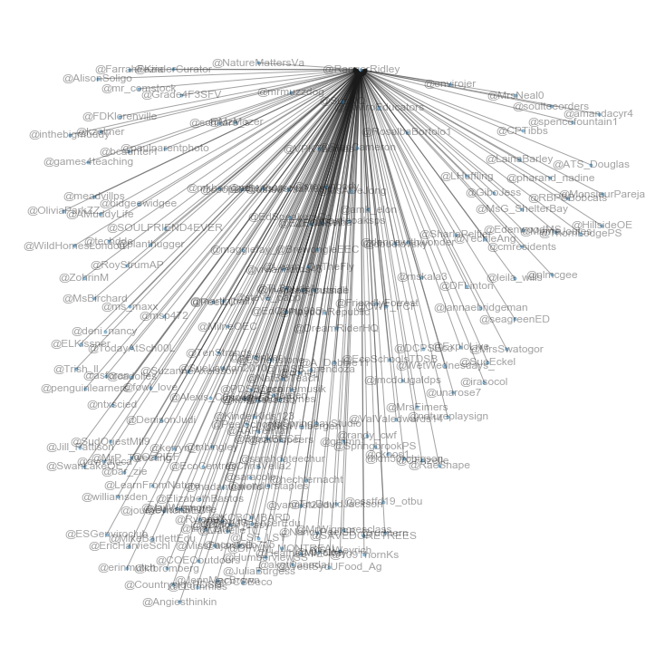

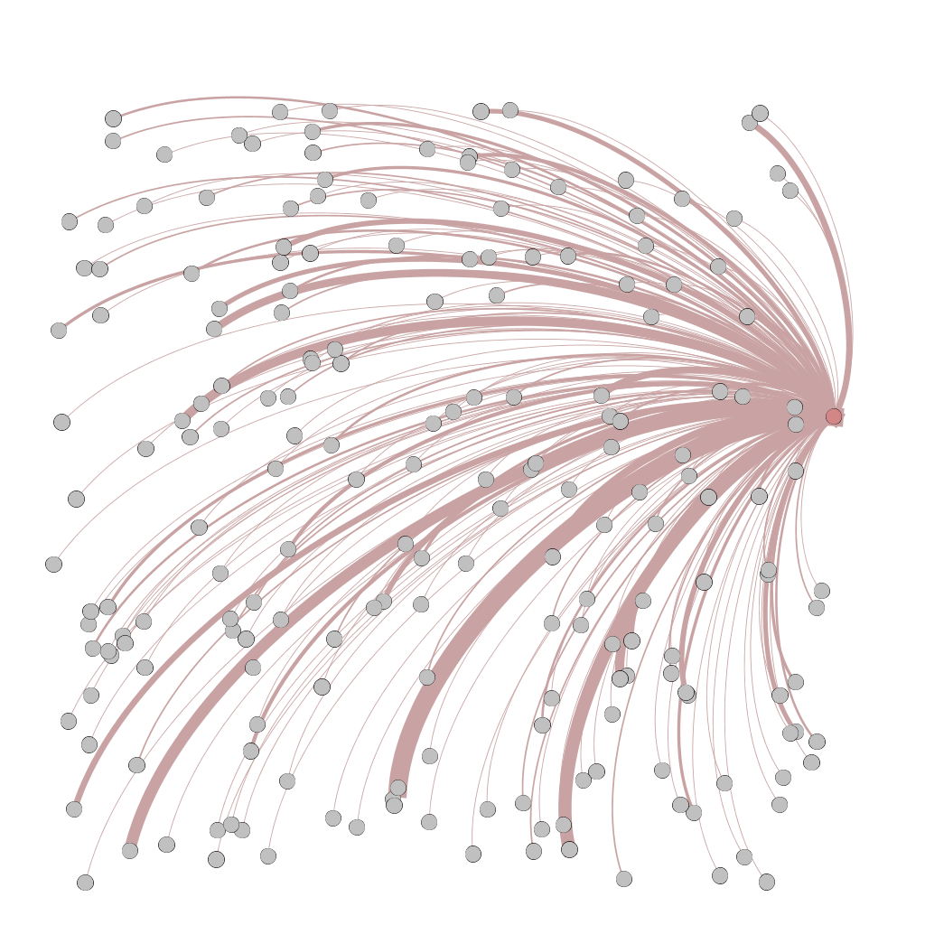

```python
name = ' @RangerRidley'# declare the user name
nodes_name = [name] # naming of the node
edges_name = [] # storage list of edges

for edge in edges: # iterate across the edges
  if edge[0] == name: # check if edge contains the name
    nodes_name.append(edge[1]) # append the name
    edges_name.append(edge) # append the mention
  elif edge[1] == name: # count if its a mention
    nodes_name.append(edge[0]) # append the name
    edges_name.append(edge) # append the name to mentions

G2 = G.subgraph(nodes_name) # create the subgraph
print(nx.info(G2)) # print sub graph's info
plt.figure(figsize=(10,10)) # set fig size
nx.draw(G2, with_labels=True, font_size=12, node_size=10, alpha=0.4) # draw the figure
plt.show() # show the figure

nx.write_gexf(G2, 'name_ridley.gexf') # export the subgraph

# Show the subgraph generated from gephi
# Ridley is the node in Red
from IPython.display import Image
Image('sna_ridley_peers.png')
```

#### **Code Commentary for 2i.vi.1**

Each of these user analyses, from a code standpoint, are the same: get the nodes, iterate across the edges to get the user's specific edges, store the content, use `networkx` and `matplotlib` together to visualize the information, export as a `Gephi` image, reimport and view the Gephi file as a portable network graphic. Tweaking the settings was also important, because each graph needed to be tweaked a little bit in order to optimize (is that an oxymoron?) viewing here in Jupyter.

#### **Observations for 2i.vi.1:**

*Look for a more technical vs. off the cuff observation set in the 2i.vii mark down cell*

I chose *@RangerRidley*, because he was what I was thinking of as a "chart topper." He was at the top of most, if not all, of the lists of top users based on a given category. I wanted to visualize a user that had what felt like a very dense or large network, just to see what that would be like.

I had a moment of you should be careful for what you wish for because he was a very tough user to analyze due to how big his network is. It was a very large `Gephi` file, however, it was fun to manipulate it in the `Gephi` window. Making the font size bigger was very helpul in understanding his network. The results can be seen above and are important to analyze in the context of other users.

#### 2i.vi.2: The First User Analysis: *@Learn_OnTheFly*

```
Name:
Type: DiGraph
Number of nodes: 14
Number of edges: 13
Average in degree:   0.9286
Average out degree:   0.9286
```

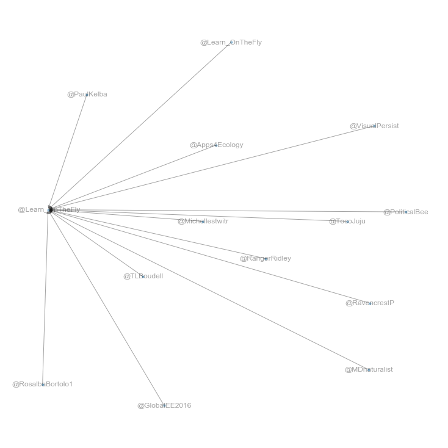

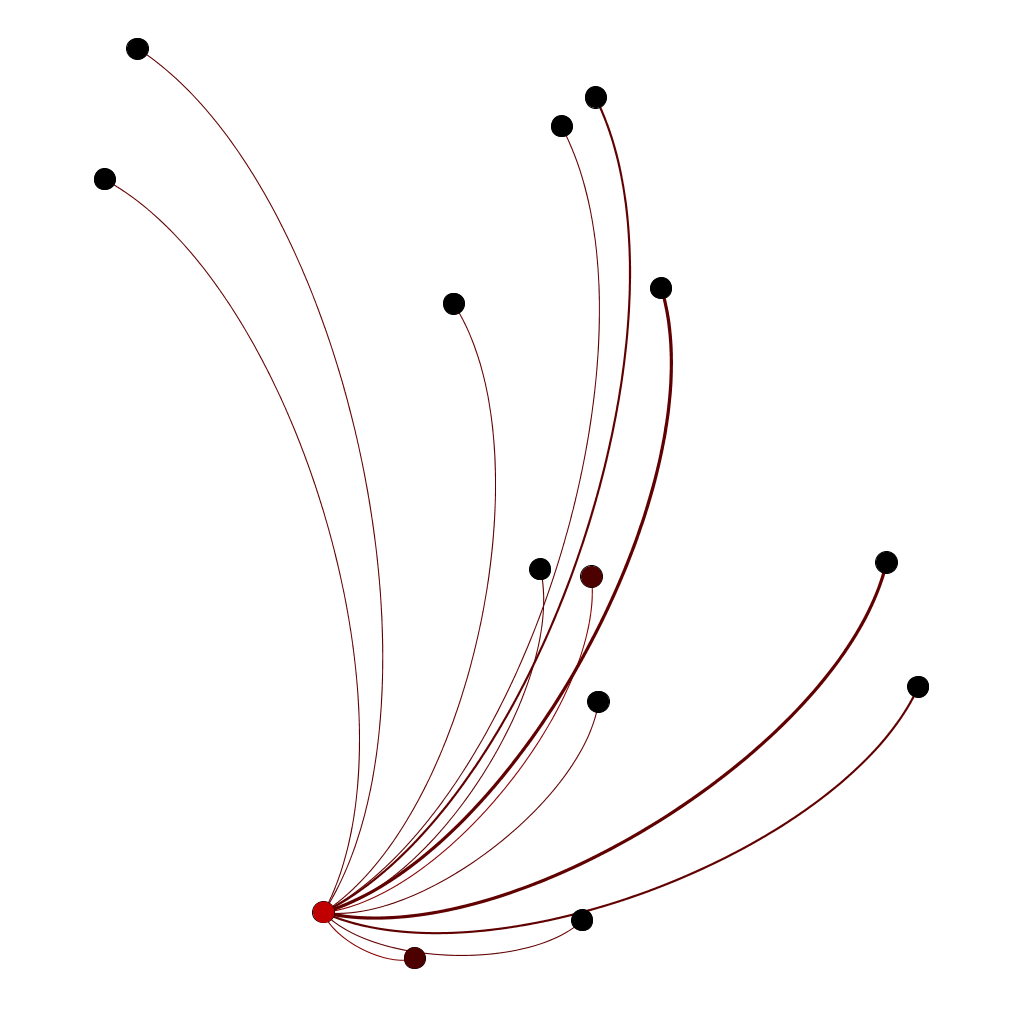

```python
name = ' @Learn_OnTheFly' # username to be measured
nodes_name = [name] # naming of the node
edges_name = [] # storage list of edges

for edge in edges: # iterate across the edges
  if edge[0] == name: # check if edge contains the name
    nodes_name.append(edge[1]) # append the name
    edges_name.append(edge) # append the mention
  elif edge[1] == name: # count if its a mention
    nodes_name.append(edge[0]) # append the name
    edges_name.append(edge) # append the name to mentions

G2 = G.subgraph(nodes_name) # create the subgraph
print(nx.info(G2)) # print sub graph's info
plt.figure(figsize=(10,10)) # set fig size
nx.draw(G2, with_labels=True, font_size=12, node_size=10, alpha=0.4) # draw the figure
plt.show() # show the figure

nx.write_gexf(G2, 'name_lotf.gexf') # export the subgraph

# show the subgraph generated from gephi
# Elon is the node in Red
from IPython.display import Image # necessary import
Image('sna_lotf_peers.png') # display the image
```

#### **Code Commentary for 2i.vi.2**

Each of these user analyses, from a code standpoint, are the same: get the nodes, iterate across the edges to get the user's specific edges, store the content, use `networkx` and `matplotlib` together to visualize the information, export as a Gephi image, reimport and view the Gephi file as a portable network graphic. Tweaking the settings was also important, because each graph needed to be tweaked a little bit in order to optimize (is that an oxymoron?) viewing here in Jupyter.

#### **Observations for 2i.vi.2:**

*Look for a more technical vs. off the cuff observation set in the 2i.vii mark down cell*

I chose @Learn_OnTheFly, because this user was a very middle of the road user (in terms of statistics) and I liked their username. They were in the middle of most of the, if not all, of the lists of top users based on a given statistical category. I wanted to visualize a user that had what felt like a very middle of the road network to compare against a user with a vast network to see which statistics changed as the network size did.

I enjoyed viewing *@Learn_OnTheFly's* network in `Gephi`, because it was a lot more digestible which was a nice relief after viewing *@RangerRidley's* network. View both above or zipped into the folder accompanying this `.ipynb` and `.html` file.

#### 2i.vi.3: The First User Analysis: *@DavidSpencerEdu*

```
Name:
Type: DiGraph
Number of nodes: 14
Number of edges: 13
Average in degree:   0.9286
Average out degree:   0.9286
```

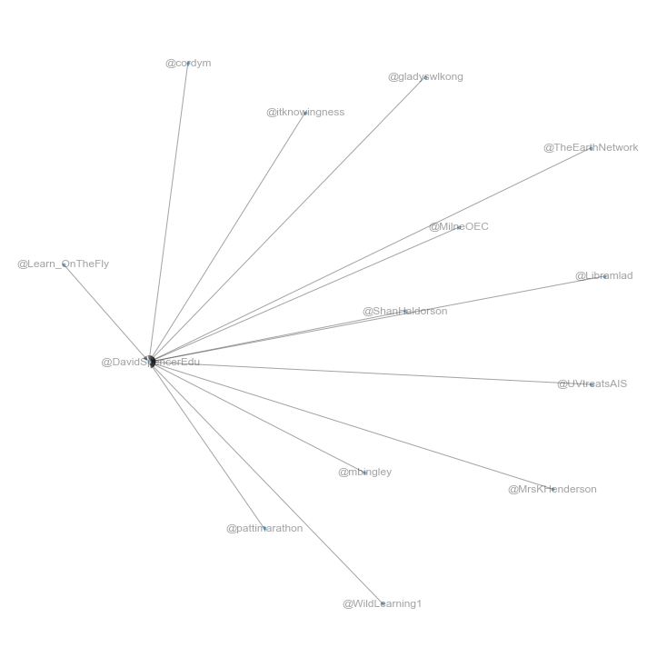

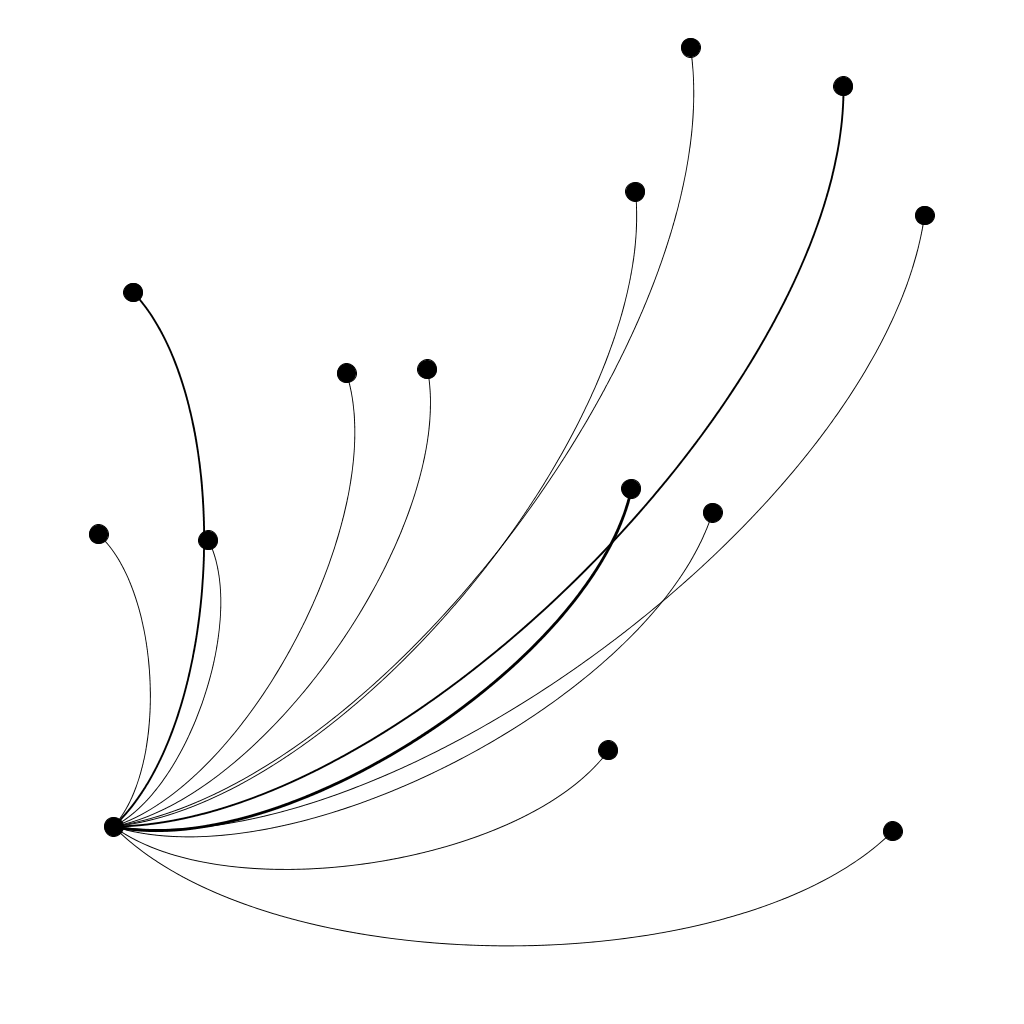

```python
name = ' @DavidSpencerEdu'
nodes_name = [name] # naming of the node
edges_name = [] # storage list of edges

for edge in edges: # iterate across the edges
  if edge[0] == name: # check if edge contains the name
    nodes_name.append(edge[1]) # append the name
    edges_name.append(edge) # append the mention
  elif edge[1] == name: # count if its a mention
    nodes_name.append(edge[0]) # append the name
    edges_name.append(edge) # append the name to mentions

G2 = G.subgraph(nodes_name) # create the subgraph
print(nx.info(G2)) # print sub graph's info
plt.figure(figsize=(10,10)) # set fig size
nx.draw(G2, with_labels=True, font_size=12, node_size=10, alpha=0.4) # draw the figure
plt.show() # show the figure

nx.write_gexf(G2, 'name_david_spencer.gexf') # export the subgraph

# Show the subgraph generated from gephi
# Elon is the node in Red
from IPython.display import Image # necessary import
Image('sna_david_spencer_peers.png') # read in and display the file
```

#### **Code Commentary for 2i.vi.3**

Each of these user analyses, from a code standpoint, are the same: get the nodes, iterate across the edges to get the user's specific edges, store the content, use `networkx` and `matplotlib` together to visualize the information, export as a Gephi image, reimport and view the Gephi file as a portable network graphic. Tweaking the settings was also important, because each graph needed to be tweaked a little bit in order to optimize (is that an oxymoron?) viewing here in Jupyter.

#### **Observations for 2i.vi.3:**

*Look for a more technical vs. off the cuff observation set in the 2i.vii mark down cell*

### 2i.vii: In a markdown cell, discuss three users you selected in terms of their graphs and assorted calculated metrics.

#### **Code Commentary for 2i.vii**

`Gephi` was very challenging to work with and I didn't have much success with visualizing the networks much better there than I had using `networx`'s tools out of the box. I spent my time visualzing my `networkx` graphs as good as I could do inline here in this Jupyter Notebook.

#### **Observations for 2i.vii:**

I itermittently explained each of these, but I can go into some broader strokes here. I chose these three different ones to explore different segements of the users out there. *@RangerRidley* is a pretty active users and frequently tweets and mentions people. *@Learn_OnTheFly* is less active, but very much a middle of the road person. Finally, *@DavidSpencerEdu* is not the most active user and his network graph shows it.

In conclusion, this data analysis revealed that, just like in group chats and on FaceBook, there are people who are very active on social media platforms. *@RangerRidley* is one of these people, whereas *@Learn_OnTheFly* and *@DrewSpencerEDU* are not. It is nice to see that the data analyis supports what I see out there in my everyday life.

## 2j: Pose an additional question or area of interest about this dataset, write code to answer it, show a visualization, and discuss your observations.

#### **Question:** How many tweets include links in them?

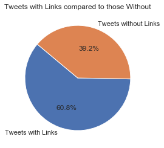

```python
df2j = data.copy() # copies the data
links = [] # storage for tweets with links
linkless = [] # storage for tweets without links
for tweet in df2j['Tweet Text']: # loop through the tweets
  if "https://t.co/" in tweet: # split the tweet up
    links.append(tweet) # append if there's a link
  else:
    linkless.append(tweet) # append if there is no link

# generate the pie plot
sizes = [len(links), len(linkless)] # set the porportions
labels = ['Tweets with Links', 'Tweets without Links'] # set the labels
plt.pie(sizes, labels=labels,autopct='%1.1f%%', startangle=140) # generate the plot
plt.title("Tweets with Links compared to those Without") # add a title
plt.show() # plot the visualization
```

#### **2j Coding Commentary:**

**Refer to 2k.i:** I did an extension of the extra credit that is a deeper dive on this original an interesting question. I used the web request data to analyze how many links are internal to Twitter.

#### **2j Observations:**

This visual, while seeming simple, is an important thing to analyze. It demonstrates how many tweets contain links and those that don't, which is good to know because it shows the depth of the network of resources for environmental education teachers out there.

## 2k: Extra Credit Questions

### 2k.i: Many tweets contain shortened URLs, such as https://t.co/QQGMPLWnZr, that redirect to another site. Figure out a way to expand these URLs to the actual link destination. (This probably involves some Googling.) Then show a count of the 50 most common URL domains (e.g., in the URL https://www.elon.edu/u/academics/arts-and-sciences/computer-science/, just the elon.edu portion). Discuss your observations.

```python
import requests # used to open the urls within tweets
from tldextract import extract # extractor
df2ki = data.copy() # copies the data
xpt = 0 # an exceptions counter

allLinks = [] # all links storage list
urls = [] # all urls storage list for cleaned urls
for tweet in df2ki['Tweet Text']: # iterates over tweet text
    allLinks.append(re.findall(r'(https?://\S+)', tweet)) # finds all the links

for item in allLinks: # iterates all the links that were found
    if len(item) == 0: # checks for null links
        allLinks.remove(item) # removes null links
    for url in item: # continues with iteration
        if url[-1:] != '…': # cleans out the crappy char
            urls.append(url) # appends it to the clean url list
c = 0 # record counter
realUrls = [] # creates a list for the actual URLS from twitter urls

# this opens each of the twitter urls
for url in urls: # iterates over each url
  try: # tries it and catches exceptions
    realUrl = requests.get(url, allow_redirects = True, timeout=4).url # opens and retrieves real url
#    print('twitter url:', url, 'real url:', realUrl, 'url', c, ' of', len(urls)) # prints out for debugging
    tsd, td, tsu = extract(realUrl) # prints abc, hostname, com
    r_url = td + '.' + tsu # will prints as hostname.com
    realUrls.append(r_url) # gets the right one and stores it
  except: # catches exceptions
    xpt += 1 # increments the number of exceptions to keep track
#    print("An exception occurred on URL ", url, " total errors now", xpt, " of", c, "records") # a debug statement to check if it works
  c += 1 # incremements the counter to keep track
```

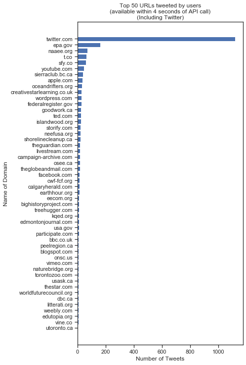

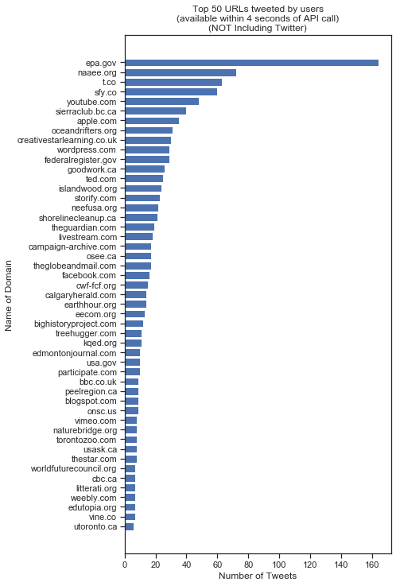

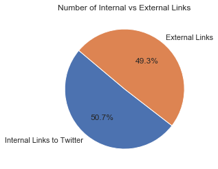

```
Percentage of External Tweets going to EPA:  17.71 %
```

```python
import collections

n = 50 # set the number of locations to be kept

## INCLUDING TWITTER
counter = collections.Counter(realUrls) # generate the dict
counter = dict(sorted(counter.items(), key = itemgetter(1), reverse = True)[:n]) # sort dict for plotting
keys = list(counter.keys()) # get x values
values = counter.values() # get y values
fig, ax = plt.subplots(figsize = (6,12)) # create the fig
ax.barh(keys, values) # generate the plot
ax.invert_yaxis() # invert y_axis
ax.set_title("Top 50 URLs tweeted by users\n(available within 4 seconds of API call)\n(Including Twitter)") # add a title
ax.set_xlabel("Number of Tweets") # add the x-axis label
ax.set_ylabel("Name of Domain") # add the y-axis label
plt.show() # plot the visualization

## NOT INCLUDING TWITTER
counter2 = collections.Counter(realUrls) # generate the dict
counter2 = dict(sorted(counter2.items(), key = itemgetter(1), reverse = True)[1:n]) # sort dict for plotting
keys = list(counter2.keys()) # get x values
values = counter2.values() # get y values
fig, ax = plt.subplots(figsize = (6,12)) # create the fig
ax.barh(keys, values) # generate the plot
ax.invert_yaxis() # invert y_axis
ax.set_title("Top 50 URLs tweeted by users\n(available within 4 seconds of API call)\n(NOT Including Twitter)") # add a title
ax.set_xlabel("Number of Tweets") # add the x-axis label
ax.set_ylabel("Name of Domain") # add the y-axis label
plt.show() # plot the visualization

## PIE CHART OF COMPOSITION
tweetsLen = counter['twitter.com'] # get the number of internal links
othersLen = sum(counter.values())-tweetsLen # get the length of other tweets
sizes = [tweetsLen, othersLen] # set the porportions
labels = ['Internal Links to Twitter', 'External Links'] # set the labels
plt.pie(sizes, labels=labels,autopct='%1.1f%%', startangle=140) # generate the plot
plt.title("Number of Internal vs External Links") # add a title
plt.show() # plot the visualization

## OTHER COMPOSITIONS
epaLen = counter['epa.gov']
epaAdjLen = othersLen - epaLen
print("Percentage of External Tweets going to EPA: ", round(epaLen/epaAdjLen*100,2), '%')
```

#### **2k.i Code Commentary:**

I used two cells to complete this challenge. The first sets all the data up and the second one counts it up and displays it. There are three main challenges here: opening the urls to get the underlying url, cleaning up and counting the domains, and then displaying it in a logical way.

The data is transformed using `requests` to make API calls to the web to get the underlying url beneath each url in a tweet. Once I learned how to use the API key and turn on timeouts, this step was a breeze; however, getting it set up was not. I wish I had learned about the parameted. This was also a pain in the behind because if I was lucky it would run in a half hour, so it took forever to get set up.

Visualizing was the easy part. I went with a horizontal bar graph opposed to a normal one, because there was enough of a difference to warrant it. Opposed to some of the others where it didn't make sense becasue the differences didn't really matter.

I did make two visuals, because it felt important to show the impact that internal twitter links had on the data set -- making two allowed to highlight how it impacted it. A quick note: I did use print statements to debug, however, removed them so that there was not 2744 lines out output.

**EPA Calculation** I calculated what percentage of external tweets go to the EPA's website because it was the next closest to internal links in terms of link composition.

### 2k.ii: Make a geospatial visualization of twitter user locations. This will require first geocoding the non-blank values in the Location column to match locations with latitude and longitude. (Suggestion: install the geocoder package on your local machine.) Once you have latitude and longitude for each tweet with a non-blank location, plot them on a map. (Suggestion: install the basemap package on your local machine.) Show a world map and one just for North America. Use transparency (alpha) to show density of tweets. Discuss your observations.

```python
import geocoder # used to get geo location data
import time # allows the code to lag to keep up with API


df2kii = data.copy() # copies the data
df2kii = df2kii.dropna(subset=['Location']) # gets rid of NaNs
df2kii = df2kii[df2kii['Location'] != None] # removes crappy lines
df2kii = df2kii[df2kii['Location'] != ''] # removes more crappy lines
lat = [] # instantiates the lat column
lng = [] # instantiates the long column
count = 1 # instantiates the count
for location in df2kii['Location']:
  try:
    g = geocoder.google(location, # tries each of the locations
                        key = 'AIzaSyDncUtY1RXYOYAYBHsfmIL9f_DIekBj6kE', # my Google API key
                        rate_limit = False) # this exceeds the standard limit so need this parameter
#     print('location:', location, ', latitude:', g.latlng[0], ', longitude:', g.latlng[1], "loc #", count) # debugging print line
    lat.append(g.latlng[0]) # stores latitude
    lng.append(g.latlng[1]) # stores longitude
  except: # occasionally weird exceptions so catching that
#     print('location:', location, ', latitude:', 0, ', longitude:', 0) # grabs it
    lat.append(0) # stores latitude
    lng.append(0) # stores longitude
  time.sleep(.01) # to offset the API call.
  count += 1 # gets the count for display purposes

# df2kii.head() # displays a head of the results
```

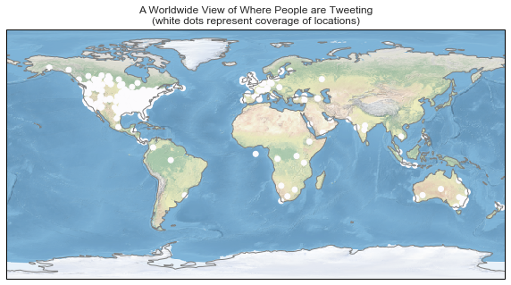

```python
import cartopy.crs as ccrs # the specific matplotlib extension
import matplotlib.pyplot as plt # reimplementing mpl

locs = {} # a storage dict
for l, ln in zip(lat,lng): # zips together two lists of lat and long
    loc = tuple([l] + [ln]) # creates a tuple
    if loc not in locs.keys(): # checks if edge already exists
      locs[loc] = 1 # initializes the key value pair
    else: # updates the key value pair if its already in the dict
      locs[loc] += 1 # increments up

latitude, longitude = [list(c) for c in zip(*locs)] # seperates out the keyvalue pair into distict lists
density = locs.values() # seperates the values into their own list
datum = tuple(zip(latitude,longitude,density)) # creates a tuple of each one to zip together for pandas df
datum = pd.DataFrame(datum,columns = ['lat', 'long','density']) # creates a pandas df to play well with mpl
lat = datum.lat # creating series for latitude
lng = datum.long # creating series for longitude
dens = datum.density # creating series for density
fig = plt.figure(figsize = (10,10)) # setting the fig size
ax = fig.add_subplot(1, 1, 1,projection=ccrs.PlateCarree()) # creating the figure with standard projection
ax.coastlines(color='gray') # adding coast lines aka countries in gray
ax.stock_img() # adds the map bacground lol
ax.scatter(lng, lat, c = dens, cmap='Purples') # laying the points on top of the grid
plt.title('A Worldwide View of Where People are Tweeting\n(white dots represent coverage of locations)') # a proper title
plt.show()
```

#### **2k.ii Code Commentary:**

I used two cells to complete this challenge. The first sets all the data up and the second one counts it up and displays it. There are three main challenges here: transforming the data from strings to latitude and longitudes, getting the tweet density per location, and then displaying it on a map.

The data is transformed using `geocoder` to make API calls to google to get the latitudes and longitudes. Once I learned how to use the API key and turn off the limits on the API calls, this step was a breeze. I used the dictionary methods using tuples to count the number of times a particular coordinate was in there and stored it as key value pairs as done many times throughout this homework. I then unzipped and massaged these into a data frame to play nicely with matplotlib.

Visualizing caused a lot of headache. The `basemap` package is deprecated or otherwise very difficult to use. So, I used this other one called `cartography` that is essentially an updated version of `basemap`. Its build off the matplotlib library so its easy and flexible to work with in python. I then used the various parameters of overlaying a scatter plot ontop of a map, which was cut down based on parameters. That about sums up 6 hours of work on this problem. A quick note: I did use `print` statements to debug, but I spared the Jupyter notebook the horror of 4744 lines of output.

#### **2k.ii Observations:**

Because I wasn't using `basemap`, I found it very difficult to get the map set to the right size and to make the colors work. I tried countless ways in this other package but it's 3:30 and I am still able to make some observations based off of the pretty good graph that I was able to produce.

The graph demonstrates that the users are not just in North America, but across the globe. However, the graph does show that the users, for the most part, are based in North America. Canada and the USA seem to be fairly equally distributed. It would be cool, if I had more time, to explore the break down now that I spent the time to analyze and properly geocode the data points, where the users come from in a more quantitative way compared to just a visual.

# Final Conclusions

*I wanted to include this section to kind of wrap up what I learned and cemented as part of this homework, because I really feel like it was a lot*

1. this notebook got very heavy and the extra credit problems were tough to run
2. probably should not have spent as much time as I did on the extra credit, but they seemed very interesting and I learned alot
3. my python knowledge grew alot during this homework. From learning how to use the dict counter technique, where you use a dictionary to keep track of weights, to becoming a master of the list comprehension, to learning how to pull in website data using the requests tool, to learning how to call an API with the GIS data, to learning how frustrating working with GIS data is. These were the main things.
4. my appreciation for pandas is much higher now
5. learning how matplotlib is far, far, far, more complex but also flexible than I already thought was very cool
6. building skills at interpreting complex objects, ie the social network was very important
7. I took commentary and code comments very seriously this homework, because it forced me to really think about what I was doing instead of plugging and chugging from previous work.
8. I cemented some classic/pythonic frameworks for data management that I didn't use before
9. I have a new found appreciation for dictionaries now.
10. sorry that this is a few hours late, please don't dock me a full ten points